# 通信技术岗位招聘和薪酬水平

## 总述

本次采集有效数据7461条（城市发布量>=100），主要分析通信技术开发与应用相关岗位招聘和薪酬水平，岗位如射频工程师、天线工程师、通信工程师、网络工程师、基带工程师、嵌入式软件工程师、硬件工程师、数据通信、FPGA、EMC、项目经理等。我们将分析如下方面：

- 01.城市分布：深圳占18%，平均月薪18832元；上海占15%，平均月薪20642元；其余城市均在9%或以下。
- 02.行业分布：通信/电信/网络设备占37%，平均月薪15862元；电子技术/半导体/集成电路占24%，平均月薪18370元
- 03.公司规模：1000人以下占74%，平均月薪15638元；1000-5000人占17%，平均月薪17687元。
- 04.公司类型：民企占57%，平均月薪14926元；外企占12%，平均月薪18781元。
- 05.工作经验：5年以下占85%，平均月薪15018元；5-10年占14%，平均月薪23001元。
- 06.学历要求：本科占58%，平均月薪17876元；大专占29%，平均月薪10862元。

## 01.城市分布

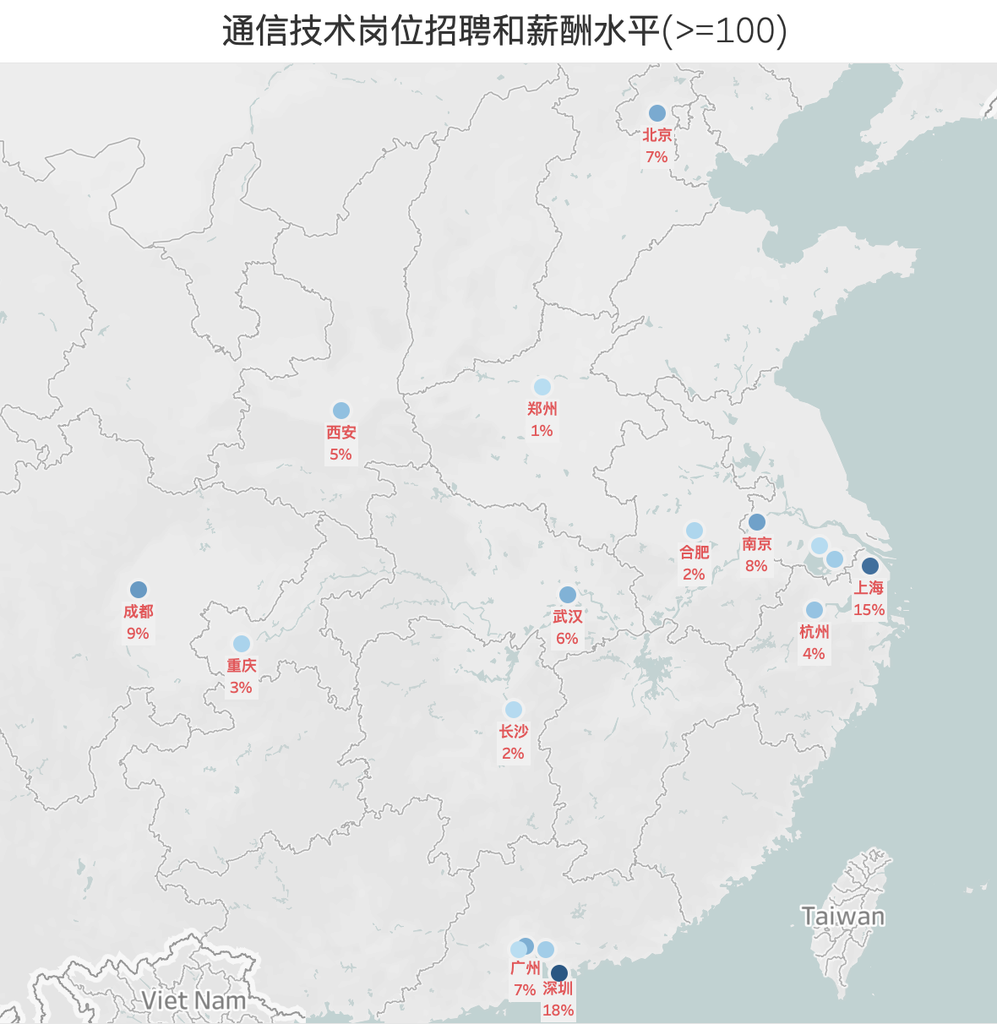

roadmap

## 02.行业分布

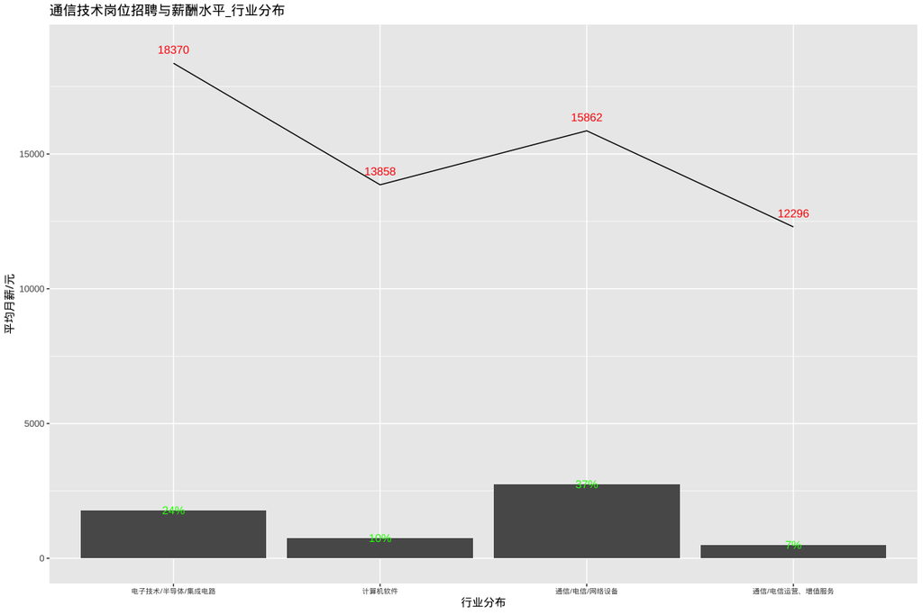

industries

## 03.公司规模

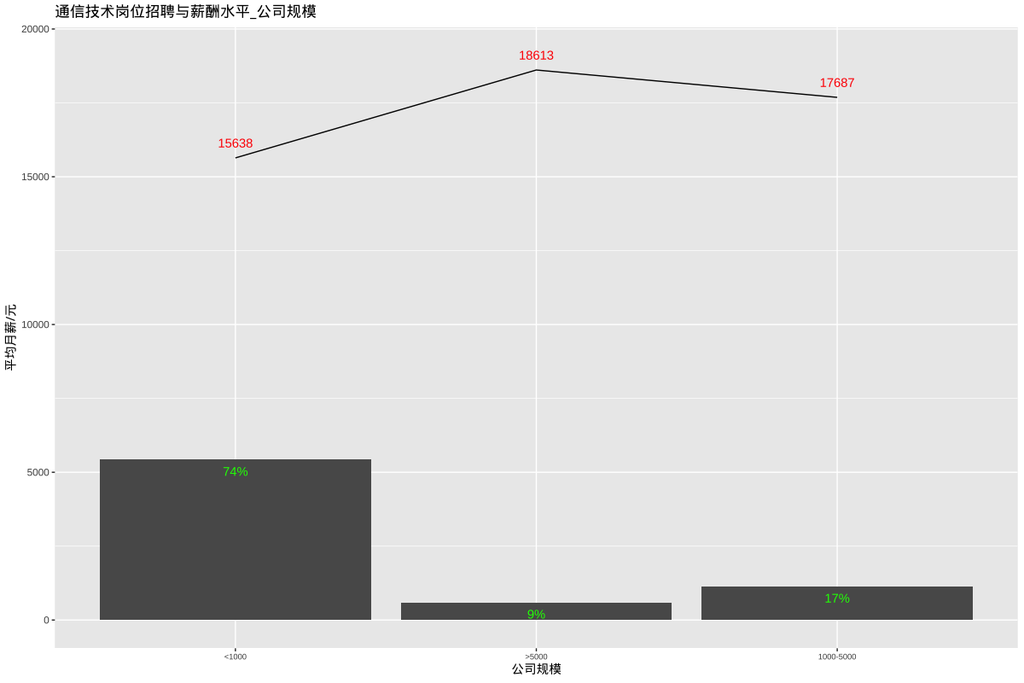

com_size

## 04.公司类型

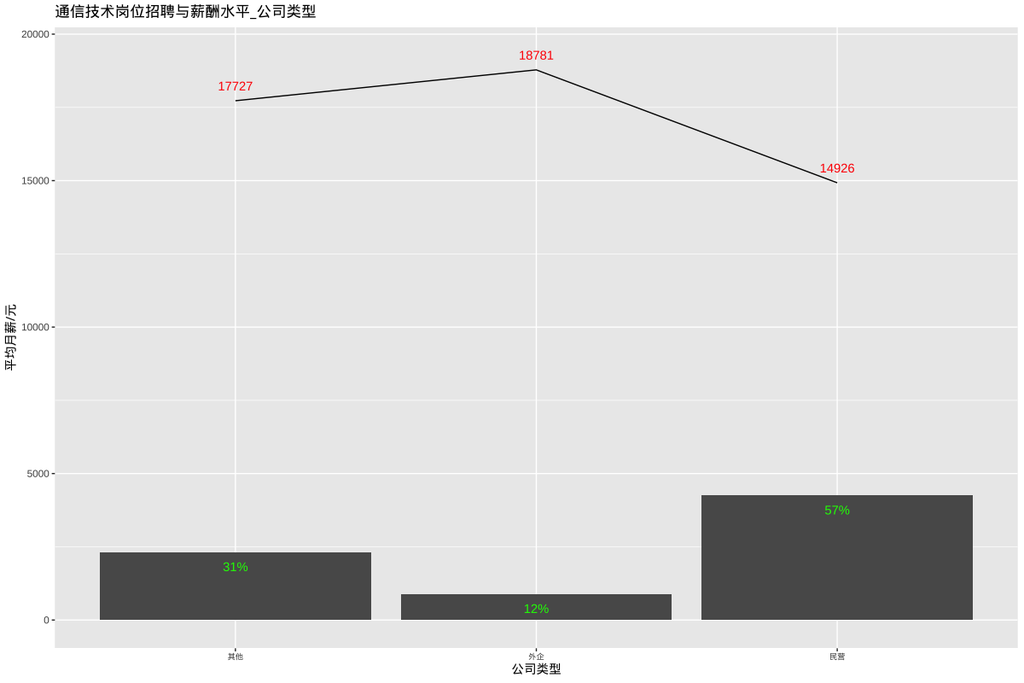

com_type

## 05.工作经验

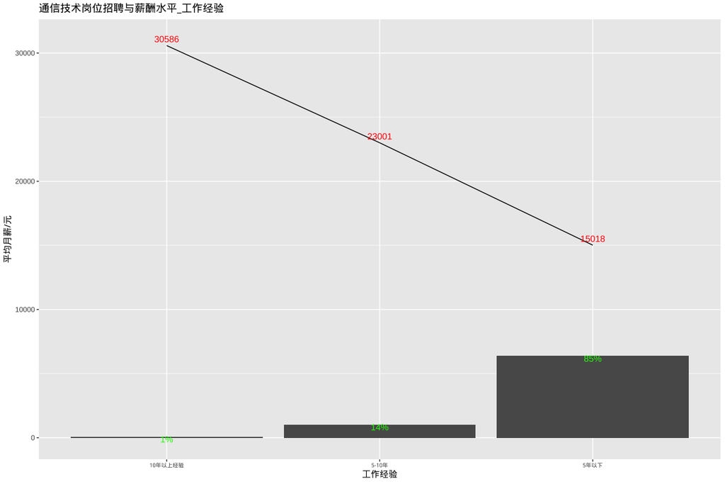

experience

## 06.学历要求

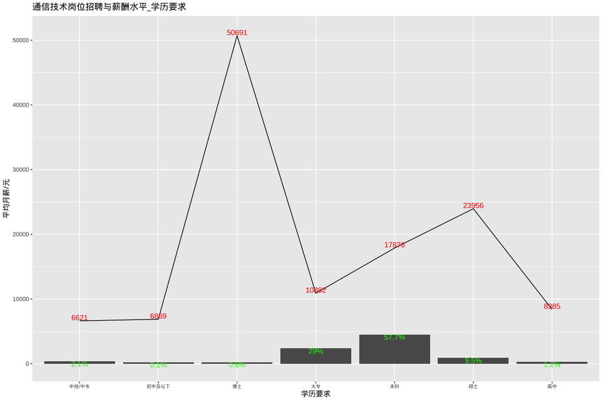

education